[figure not shown]

# [Ahmet Kaya **Data Science Blog**](https://ahmtkaya.github.io/)

# k-means with Three Different Distance Metrics by Using Feature Extraction

We will apply Feature Extraction to Iris data and compare three different Distance Metrics. In this project We will use Iris data to compare three different Distance Metrics. The power of k-means algorithm is due to its computational efficiency and the nature of ease at which it can be used. Distance metrics are used to find similar data objects that lead to develop robust algorithms for the data mining functionalities such as classification and clustering.

# 1.Basic Euclidean Distance Metric:

Euclidean distance computes the root of square difference between co-ordinates of pair of objects.

$Distance=\sqrt{\left(\sum_{k=1}^m (x_{ik}-x_{jk} \right)^2)}$

```python
import numpy as np
import pandas as pd
import seaborn as sns
from matplotlib import pyplot as plt
```

```python
df=pd.read_csv('https://raw.githubusercontent.com/uiuc-cse/data-fa14/gh-pages/data/iris.csv')
df['euclidean']=np.sqrt(df.petal_length**2+df.petal_width**2)
df.head()
```

|  | sepal_length | sepal_width | petal_length | petal_width | species | euclidean |
| --- | --- | --- | --- | --- | --- | --- |
| 0 | 5.1 | 3.5 | 1.4 | 0.2 | setosa | 1.414214 |
| 1 | 4.9 | 3.0 | 1.4 | 0.2 | setosa | 1.414214 |
| 2 | 4.7 | 3.2 | 1.3 | 0.2 | setosa | 1.315295 |
| 3 | 4.6 | 3.1 | 1.5 | 0.2 | setosa | 1.513275 |
| 4 | 5.0 | 3.6 | 1.4 | 0.2 | setosa | 1.414214 |

# 1.1. Find the cluster center:

Data point is assigned to the cluster center whose distance from the cluster center is minimum of all the cluster centers. We are assuming we have 3 clusters. $Center (x,y)=(\left(\sum_{i=1}^N \frac{x_i}{N}\right), \left(\sum_{i=1}^N \frac{y_i}{N}\right))$

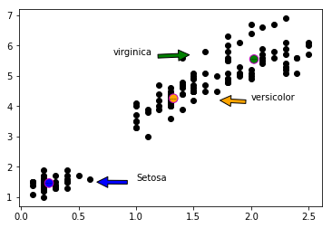

```python
plt.plot(df.iloc[:,3:4],df.iloc[:,2:3],"o",color='black')
plt.annotate('Setosa', xy=(0.6,1.5), xytext=(1,1.55),
            arrowprops=dict(facecolor='blue', shrink=0.15),
            )
bbox_Circle = dict(boxstyle="Circle,pad=0.3", fc="b", ec="m", alpha=1)
plt.text(df[df.species=='setosa'].iloc[:,3:4].mean(), df[df.species=='setosa'].iloc[:,2:3].mean(), "virginica", ha="center", va="center", size=2,bbox=bbox_Circle)
plt.annotate('versicolor', xy=(1.7,4.2), xytext=(2,4.2),
            arrowprops=dict(facecolor='orange', shrink=0.1),
            )
bbox_Circle = dict(boxstyle="Circle,pad=0.3", fc="orange", ec="m", alpha=1)
plt.text(df[df.species=='versicolor'].iloc[:,3:4].mean(), df[df.species=='versicolor'].iloc[:,2:3].mean(), "virginica", ha="center", va="center", size=2,bbox=bbox_Circle)
plt.annotate('virginica', xy=(1.5,5.7), xytext=(0.8,5.7),
            arrowprops=dict(facecolor='g', shrink=0.1),
            )
bbox_Circle = dict(boxstyle="Circle,pad=0.3", fc="g", ec="m", alpha=1)
plt.text(df[df.species=='virginica'].iloc[:,3:4].mean(), df[df.species=='virginica'].iloc[:,2:3].mean(), "virginica", ha="center", va="center", size=2,bbox=bbox_Circle)
plt.show()
```

Three different clusters will be plotted with three different color

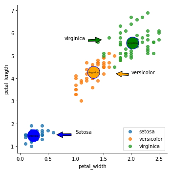

```python
# Use the 'hue' argument to provide a factor variable
g=sns.lmplot( x="petal_width", y="petal_length", data=df, fit_reg=False, hue='species', legend=False)
plt.annotate('Setosa', xy=(0.6,1.5), xytext=(1,1.55),
            arrowprops=dict(facecolor='blue', shrink=0.15),
            )
bbox_Circle = dict(boxstyle="Circle,pad=0.3", fc="blue", ec="b", alpha=1)
plt.text(df[df.species=='setosa'].iloc[:,3:4].mean(), df[df.species=='setosa'].iloc[:,2:3].mean(), "virginica", ha="center", va="center", size=5,bbox=bbox_Circle)
plt.annotate('versicolor', xy=(1.7,4.2), xytext=(2,4.2),
            arrowprops=dict(facecolor='orange', shrink=0.1),
            )
bbox_Circle = dict(boxstyle="Circle,pad=0.3", fc="orange", ec="b", alpha=1)
plt.text(df[df.species=='versicolor'].iloc[:,3:4].mean(), df[df.species=='versicolor'].iloc[:,2:3].mean(), "virginica", ha="center", va="center", size=5,bbox=bbox_Circle)
plt.annotate('virginica', xy=(1.5,5.7), xytext=(0.8,5.7),
            arrowprops=dict(facecolor='g', shrink=0.1),
            )
bbox_Circle = dict(boxstyle="Circle,pad=0.3", fc="green", ec="b", alpha=1)
plt.text(df[df.species=='virginica'].iloc[:,3:4].mean(), df[df.species=='virginica'].iloc[:,2:3].mean(), "virginica", ha="center", va="center", size=5,bbox=bbox_Circle)

# Move the legend to an empty part of the plot
plt.legend(loc='lower right')
```

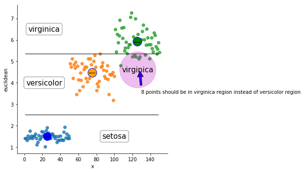

```python
#plot to see clusters.
x=[]
for i in range (1,151):
    x.append(i)
df['x']=x
g=sns.lmplot( x='x', y="euclidean", data=df, fit_reg=False, hue='species', legend=False)
bbox_Circle = dict(boxstyle="Circle,pad=0.3", fc="b", ec="b", alpha=1)
plt.text(df[df.species=='setosa']['x'].mean(), df[df.species=='setosa']['euclidean'].mean(), "setos", ha="center", va="center", size=5,bbox=bbox_Circle)
bbox_Circle = dict(boxstyle="Circle,pad=0.3", fc="orange", ec="b", alpha=1)
plt.text(df[df.species=='versicolor']['x'].mean(), df[df.species=='versicolor']['euclidean'].mean(), "versic", ha="center", va="center", size=5,bbox=bbox_Circle)
bbox_Circle = dict(boxstyle="Circle,pad=0.3", fc="g", ec="b", alpha=1)
plt.text(df[df.species=='virginica']['x'].mean(), df[df.species=='virginica']['euclidean'].mean(), "versic", ha="center", va="center", size=5,bbox=bbox_Circle)

plt.annotate("",
              xy=(0, 5.345), xycoords='data',
              xytext=(150, 5.345), textcoords='data',
              arrowprops=dict(arrowstyle="-",
                              connectionstyle="arc3,rad=0."),
              )
plt.annotate("",
              xy=(0, 2.5), xycoords='data',
              xytext=(150, 2.5), textcoords='data',
              arrowprops=dict(arrowstyle="-",
                              connectionstyle="arc3,rad=0."),
              )
plt.annotate('8 points should be in virginica region instead of versicolor region', xy=(128, 4.7), xytext=(130, 3.5),
            arrowprops=dict(facecolor='blue', shrink=0.15),
            )
bbox_props = dict(boxstyle="round", fc="w", ec="0.5", alpha=0.9)
plt.text(100, 1.5, "setosa", ha="center", va="center", size=15,bbox=bbox_props)
plt.text(22, 4, "versicolor", ha="center", va="center", size=15,bbox=bbox_props)
plt.text(22, 6.5, "virginica", ha="center", va="center", size=15,bbox=bbox_props)
bbox_Circle = dict(boxstyle="Circle,pad=0.3", fc="m", ec="m", alpha=0.25)
plt.text(126, 4.6, "virginica", ha="center", va="center", size=15,bbox=bbox_Circle)
plt.show()
```

```python
bins = [0, df[df.species=='setosa']['euclidean'].max(), df[df.species=='versicolor']['euclidean'].max(),
        df[df.species=='virginica']['euclidean'].max()]
df['binned'] = pd.cut(df['euclidean'], bins)
df = df.copy()
df = pd.get_dummies(df, columns=['binned'], prefix = ['binned'])
df.head()
```

|  | sepal_length | sepal_width | petal_length | petal_width | species | euclidean | x | binned_(0.0, 1.942] | binned_(1.942, 5.345] | binned_(5.345, 7.273] |
| --- | --- | --- | --- | --- | --- | --- | --- | --- | --- | --- |
| 0 | 5.1 | 3.5 | 1.4 | 0.2 | setosa | 1.414214 | 1 | 1 | 0 | 0 |
| 1 | 4.9 | 3.0 | 1.4 | 0.2 | setosa | 1.414214 | 2 | 1 | 0 | 0 |
| 2 | 4.7 | 3.2 | 1.3 | 0.2 | setosa | 1.315295 | 3 | 1 | 0 | 0 |
| 3 | 4.6 | 3.1 | 1.5 | 0.2 | setosa | 1.513275 | 4 | 1 | 0 | 0 |
| 4 | 5.0 | 3.6 | 1.4 | 0.2 | setosa | 1.414214 | 5 | 1 | 0 | 0 |

```python
confusion_matrix=df.groupby(['species']).sum().iloc[:,6:9]
confusion_matrix.columns = ['setosa_predict','versicolor_predict', 'virginica_predict']
confusion_matrix
```

| species | setosa_predict | versicolor_predict | virginica_predict |
| --- | --- | --- | --- |
| setosa | 50 | 0 | 0 |
| versicolor | 0 | 50 | 0 |
| virginica | 0 | 8 | 42 |